# El cambio climático impulsa cambios en la distribución de poblaciones de peces transfronterizos migratorios en los océanos del mundo

Juliano Palacios-Abrantes, Bianca S. Santos, Thomas Frölicher, Gabriel Reygondeau, Rashid Sumaila, Colette C.C. Wabnitz and William W.L. Cheung

Publicación y traducción, 2025

[figure not shown]

- **NOTA: esta es una traducción al español del artículo:** Climate change drives shifts in straddling fish stocks in the world’s ocean, escrito por Palacios-Abrantes J.y colaboradores y que se puede encontrar en la siguiente [liga](https://www.science.org/doi/10.1126/sciadv.adq5976). No cuenta con la sección de Métodos traducida.
  - Traducido por Juliano Palacios. Revisión técnica de Guillermo Palacios.
- **Forma de Citar**: Palacios-Abrantes, J., Santos, B. S., Frölicher, T. L., Reygondeau, G., Sumaila, U. R., Wabnitz, C. C. C. and Cheung, W. W. L., 2025. Climate change drives shifts in straddling fish stocks in the world’s ocean. *Science Advances*, adq5976 (11).

Descargar Artículo en Español

# Resumen

Los cambios en la distribución de especies a partir del cambio climático representan un desafío particular para las pesquerías que capturan poblaciones de peces compartidas entre Zonas Eeconómicas Exclusivas (ZEE) y alta mar, conocidas como poblaciones transfronterizas (*straddling stocks*). En este estudio, combinamos múltiples conjuntos de datos y modelos ecosistémicos para identificar la presencia de poblaciones transfronterizas a nivel mundial y considerar lo que significan para la gestión pesquera bajo cambio climático. Identificamos 347 poblaciones transfronterizas pertenecientes a 67 especies, incluyendo tanto especies altamente migratorias como otras menos móviles. Nuestros resultados sugieren que, independientemente del escenario climático, al menos el 37% y el 54% de las poblaciones están proyectadas a cambiar entre ZEE y alta mar para los años 2030 y 2050, respectivamente. Se espera que más poblaciones se desplacen hacia alta mar, y que las especies altamente migratorias se muevan entre distintas Organizaciones Regionales de Ordenación Pesquera (OROP, *RFMO en inglés*). Los Estados costeros y las OROP deben revisar sus marcos de gobernanza para apoyar una adaptación sostenible y equitativa ante el desplazamiento de las poblaciones. Desarrollar estas estrategias requiere cooperación entre los organismos de gestión dentro de las ZEE y en alta mar.

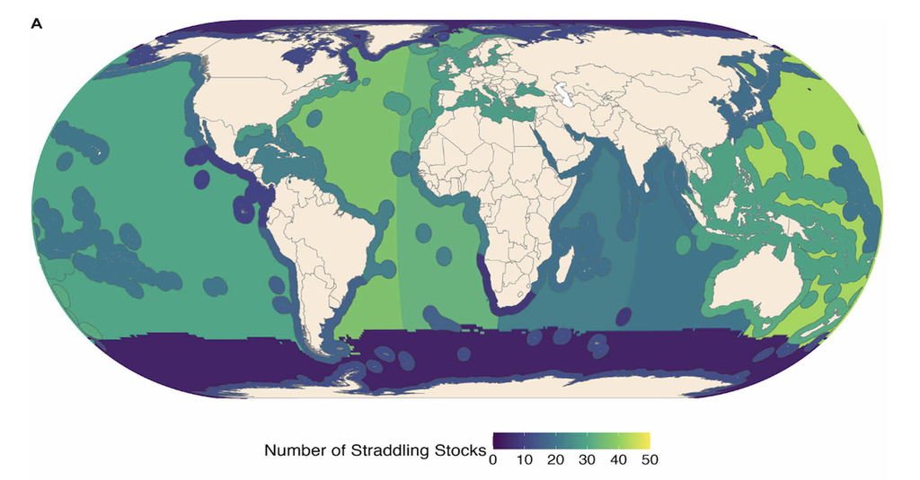

**Mapa mostrando el número de poblaciones de especies transfronterizas migratorias que visitan la alta mar (Imagen original, Palacios-Abrantes et al. 2025, Figure 1)**

# Introducción

La biogeografía de las especies marinas está determinada por factores históricos y contemporáneos, como su historia evolutiva y biología, las condiciones ambientales circundantes, y factores antropogénicos como la pesca. En particular, la distribución de ectotermos marinos, como peces e invertebrados, está fuertemente determinada por las condiciones oceánicas, incluyendo la temperatura, el oxígeno, la salinidad y la producción primaria neta (1). Mientras que la gestión y gobernanza pesquera están ligadas a límites geográficos definidos por los humanos, las especies marinas no lo están. Sus movimientos complejos y uso del hábitat pueden incluir las ZEE de múltiples naciones y aguas fuera de jurisdicción nacional (en adelante denominadas como “alta mar”). Así, muchas poblaciones de peces e invertebrados explotadas están compartidas a través de áreas oceánicas definidas políticamente pero ecológicamente contiguas.

Las poblaciones compartidas pueden clasificarse en cuatro categorías no excluyentes: (*i*) Transfronterizas: compartidas entre Zonas Economicas Exclusivas (ZEE) vecinas, (*ii*) Transfronterizas migratorias: (straddling) compartidas entre ZEE vecinas y la alta mar, (*iii*) Transfronterizas altamente migratorias: cuando cruzan múltiples ZEE y la alta mar (*iv*) Discretas de alto mar: cuando su distribución se restringe únicamente a la alta mar (2). Estas poblaciones suelen ser gestionadas por Organizaciones Regionales de Ordenación Pesquera (OROP, *RFMO e inglés*). Entre las 18 OROP que operan a nivel mundial, cinco gestionan exclusivamente especies altamente migratorias (en su mayoría atunes); éstas son: la Comisión para la Conservación del Atún Rojo del Sur (CCSBT); la Comisión Interamericana del Atún Tropical (CIAT,*IATTC e inglés*); la Comisión Internacional para la Conservación del Atún Atlántico (CICAA *ICCAT en inglés*); la Comisión del Atún del Océano Índico (CAOI, *IOTC en inglés*) y la Comisión de Pesca del Pacífico Occidental y Central (WCPFC). Todas estas OROP tienen áreas específicas y cubren múltiples especies, con la excepción de la CCSBT, que gestiona una única especie de atún sin un área de convenio específica. Las otras 13 OROP gestionan otras poblaciones de peces transfronterizos y especies discretas de alta mar, como salmones y peces planos (3). Estudios anteriores han identificado miles de poblaciones transfronterizas (4, 5), con una captura total estimada de 48 millones de toneladas, valoradas en 77 mil millones de dólares en 2014 (4), mientras que las capturas de especies altamente migratorias (en su mayoría especies de atún de importancia comercial) fueron valoradas en 11.7 mil millones de dólares en 2018 (6).

La gestión de poblaciones compartidas es más desafiante que la de especies restringidas a una sola ZEE. Depende de la correcta identificación de los límites de distribución, la importancia de las poblaciones para los usuarios del recurso, y la colaboración entre los usuarios y gestores del recurso (7–9). Por lo tanto, las poblaciones de peces tienen mayor probabilidad de ser sobreexplotadas cuando son compartidas, en comparación con aquellas confinadas a una sola ZEE (10–12). Uno de los principales retos para identificar poblaciones compartidas y estimar su importancia para las pesquerías es que los límites de distribución de las poblaciones a menudo no están claros, lo que dificulta determinar la naturaleza de dicha compartición (por ejemplo, si son transfronterizas o transfronterizas migratorias) (13). Una delimitación precisa de las poblaciones requiere una comprensión sólida de la biogeografía de las especies y consenso entre los países en cuyas aguas habitan las poblaciones (7, 8).

El cambio climático está añadiendo otra capa de complejidad al estudio, gobernanza y gestión de las poblaciones transfronterizas (14), pues está provocando desplazamientos en la distribución de especies marinas, muchas de las cuales se están moviendo hacia latitudes más altas, aguas más profundas o a lo largo de gradientes ambientales locales, como corrientes y sistemas de surgencia localizados (15). Estos desplazamientos modifican la compartición de poblaciones entre límites jurisdiccionales y de gestión (16). Investigaciones recientes han resaltado las consecuencias de estos desplazamientos para la gestión de poblaciones transfronterizas (14, 17), incluyendo la posible aparición de nuevas poblaciones (18) y la salida de algunas de las ZEE (19). Sin embargo, la magnitud de los desplazamientos en la distribución de las poblaciones transfronterizas migratorias aún no se ha determinado cuantitativamente (es decir, incluyendo el alto mar), lo que limita nuestra capacidad de gobernar eficazmente dichas poblaciones bajo distintos escenarios de cambio climático (20).

Este estudio explora el impacto del cambio climático en la distribución global de las poblaciones de peces transfronterizos migratorios. Específicamente, buscamos identificar las poblaciones que se distribuyen entre el alto mar y las zonas económicas exclusivas (ZEE), e investigar cambios en la proporción de la distribución de estas poblaciones dentro de las ZEE frente al alto mar. Nuestras hipótesis son que: (*i*) las poblaciones transfronterizas están compuestas en su mayoría por especies pelágicas de gran tamaño, y (*ii*) su proporción relativa entre el alto mar y las ZEE se verá alterada a lo largo del siglo XXI como consecuencia del cambio climático. Primero, identificamos las poblaciones transfronterizas migratorias en todo el mundo y proyectamos sus distribuciones utilizando un modelo mecanístico de dinámica poblacional impulsado por datos de tres modelos del sistema terrestre (*Earth System Models*, ESMs) bajo dos escenarios de cambio climático diferentes: un escenario de bajas emisiones (SSP1-2.6, Vía Socioeconómica Compartida 1 – Ruta de Concentración Representativa 2.6) y uno de altas emisiones (SSP5-8.5). Luego, examinamos los posibles desplazamientos impulsados por el clima entre ZEE y alto mar y discutimos los desafíos de gobernanza para la gestión de poblaciones compartidas internacionalmente, destacando la necesidad de estrategias internacionales dinámicas. Además, analizamos los cambios en la distribución de especies transfronterizas altamente migratorias en el ámbito de las OROP de atún. Este estudio contribuye al creciente cuerpo de literatura sobre los movimientos de especies marinas en una era de rápido cambio ambiental, enfocando los desplazamientos de hábitat impulsados por el clima en poblaciones de importancia económica, y sus implicaciones para la gestión y gobernanza pesquera internacional.

# Resultados

## Identificación de poblaciones

**Identificación de poblaciones transfronterizas migratorias**  
Nuestros resultados sugieren que 67 especies comerciales transfronterizas que visitan la alta mar (incluyendo 15 especies altamente migratorias según la Convención de las Naciones Unidas sobre el Derecho del Mar – UNCLOS) comprenden al menos 347 poblaciones de peces e invertebrados en todo el mundo (ver Tabla S1). La mayoría (57%) son especies pelágicas grandes. Las ZEE de Australasia templada, el Indo-Pacífico central y el Atlántico Norte templado albergan el mayor número de estas poblaciones ([Fig. 1A](https://www.science.org/cms/10.1126/sciadv.adq5976/asset/5bf2f0d3-7de2-4c6d-a575-25199bb72a44/assets/images/large/sciadv.adq5976-f1.jpg)). Las especies altamente migratorias como los atunes y los peces picudos (billfishes) fueron el grupo comercial más compartido en todas las regiones. Entre las 10 especies más compartidas se encuentran: tiburón sedoso (*Carcharhinus falciformis*), tiburón azul (*Prionace glauca*), peto (*Acanthocybium solandri*), atún listado (*Katsuwonus pelamis*) y atún de aleta amarilla (*Thunnus albacares*). Las ZEE de Sudamérica templada son las únicas donde no predominan las especies transfronterizas altamente migratorias. En cambio, dichas ZEE están caracterizadas por especies menos móviles como el jurel chileno (*Trachurus murphyi*), que se distribuye entre las ZEE de Chile y Perú y la merluza negra o bacalao austral (*Dissostichus eleginoides*), que se encuentra en las ZEE de Argentina, Uruguay y las Islas Malvinas (Falkland Islands). Estas especies representan algunas de las poblaciones más importantes en la región.

## Desplazamientos por el cambio climático

**Desplazamientos de las poblaciones transfronterizas por el cambio climático**

A nivel de grupo comercial, se proyecta que más poblaciones de casi todos los grupos tendrán desplazamientos significativos hacia 2050 ([Fig. 2](https://www.science.org/cms/10.1126/sciadv.adq5976/asset/fcbfddf1-f712-439d-8103-24f90265153d/assets/images/large/sciadv.adq5976-f2.jpg)). Para algunos grupos, estos desplazamientos estarán predominantemente dirigidos a las ZEE, por ejemplo: especies similares al arenque y al lenguado, como la platija americana (*Hippoglossoides platessoides*), compartida por Canadá y EE. UU., y también presente en el área del Banco de Flemish (alta mar del Atlántico Noroeste). En contraste, los pequeños pelágicos y calamares, como el calamar volador japonés (*Todarodes pacificus*), que se distribuye entre las ZEE de China, Japón y Rusia, se proyectan a desplazarse hacia la alta mar. De forma destacada, sólo el grupo de salmones, eperlano y especies similares no se proyectan a experimentar desplazamientos significativos. Este grupo incluye, por ejemplo, al capelán (*Mallotus villosus*), que se distribuye en el Atlántico Norte, entre Noruega, Groenlandia (Dinamarca), Islandia y Rusia. Finalmente, la mayoría de las especies transfronterizas altamente migratorias se proyectan a desplazarse desde las ZEE hacia la alta mar a nivel global, especialmente alrededor de 2050.

## Desplazamientos a través de fronteras internacionales

**Desplazamientos de especies transfronterizas migratorias a través de fronteras internacionales**  
Nuestros análisis muestran variaciones regionales sustanciales en los patrones de desplazamiento proyectados de las poblaciones transfronterizas migratorias. Casi todas las regiones (11 de 12) se proyectan a experimentar un desplazamiento de estas poblaciones hacia la alta mar tan pronto como en 2030 ([Fig. 3A](https://www.science.org/cms/10.1126/sciadv.adq5976/asset/19a50002-a6cb-4726-990f-caab13857dbc/assets/images/large/sciadv.adq5976-f3.jpg) y Fig. S1A). En sentido contrario, 10 regiones proyectan un aumento de poblaciones transfronterizas migratorias hacia las ZEE en el mismo período ([Fig. 3B](https://www.science.org/cms/10.1126/sciadv.adq5976/asset/19a50002-a6cb-4726-990f-caab13857dbc/assets/images/large/sciadv.adq5976-f3.jpg) y Fig. S1B). La región del Indo-Pacífico central (por ejemplo, Palau, Filipinas, Islas Salomón) muestra la mayor variabilidad: el 58% de las poblaciones transfronterizos se proyectan a aumentar su SSR en alta mar mientras que ninguna población se proyecta a aumentar su SSR dentro de las ZEE ([Fig. 3B](https://www.science.org/cms/10.1126/sciadv.adq5976/asset/19a50002-a6cb-4726-990f-caab13857dbc/assets/images/large/sciadv.adq5976-f3.jpg)). Entre las especies en desplazamiento se encuentran importantes especies altamente migratorias como atún listado, atún de aleta amarilla y atún patudo/ojo grande (*Thunnus obesus*), así como especies transfronterizas que no son altamente migratorias como el calamar volador japonés y la caballa japonesa (*Scomber japonicus*). Un patrón similar se proyecta para el Pacífico oriental tropical (por ejemplo, Ecuador, Colombia, Costa Rica), aunque con un número menor de poblaciones desplazándose. A medida que las poblaciones se dirigen hacia los polos bajo ambos escenarios, las ZEE del Ártico (Groenlandia, Canadá, Islandia) y del Océano Austral (Nueva Zelanda y territorios de ultramar) se proyectan a experimentar los mayores aumentos en SSR provenientes de la alta mar ([Fig. 3B](https://www.science.org/cms/10.1126/sciadv.adq5976/asset/19a50002-a6cb-4726-990f-caab13857dbc/assets/images/large/sciadv.adq5976-f3.jpg), Fig. S1B y Fig. S2B/D). En general, las ZEE tropicales están proyectadas a sufrir una pérdida neta de SSR (calculada como el número de poblaciones que ganan SSR menos aquellas que lo pierden), debido al desplazamiento hacia la alta mar, sin importar el escenario climático ni el horizonte temporal (Fig. S3). Por el contrario, las ZEE templadas se proyectan a tener ganancias netas en SSR (Fig. S3A), con dos excepciones: las ZEE templadas de Australasia en 2050 bajo un escenario de bajas emisiones, y las regiones de Sudáfrica en 2030 bajo el mismo escenario.

## Desplazamientos entre OROP

**Desplazamientos de especies transfronterizas altamente migratorias entre OROP**

Proyectamos desplazamientos de especies transfronterizas altamente migratorias (es decir, la mayoría de los atunes, peces picudos, tiburones y rayas) entre Organizaciones Regionales de Ordenación Pesquera vecinas (OROP, *RFMO por sus siglas en inglés*), además de entre las OROP y las ZEE (véase Materiales y Métodos). Se prevé que el 19 y el 25% de las poblaciones cambiarán entre OROP para el año 2030 bajo escenarios de bajas y altas emisiones, respectivamente ([Fig. 5](https://www.science.org/cms/10.1126/sciadv.adq5976/asset/af42693c-8e8a-48d7-8610-ac51813ea961/assets/images/large/sciadv.adq5976-f5.jpg) y fig. S5). Para el año 2050, esta proporción aumentará al 32% y 41%, respectivamente. En general, se proyectan cambios netos hacia el este y hacia los polos en la SSR de existencias altamente migratorias entre OROP vecinas ([Fig. 5](https://www.science.org/cms/10.1126/sciadv.adq5976/asset/af42693c-8e8a-48d7-8610-ac51813ea961/assets/images/large/sciadv.adq5976-f5.jpg) y fig. S5). Para 2030, se espera que la CIAT y la CCSBT tengan ganancias netas en la SSR provenientes de todas las OROP vecinas, a diferencia de la CICAA y la WCPFC. La OROP del océano Índico (CAOI) es la única que se proyecta que tanto gane como pierda existencias respecto de organizaciones vecinas, incluyendo posibles desplazamientos hacia la CCSBT, así como desde la WCPFC. en el mar de Java, donde ambas jurisdicciones se solapan ([Fig. 5](https://www.science.org/cms/10.1126/sciadv.adq5976/asset/af42693c-8e8a-48d7-8610-ac51813ea961/assets/images/large/sciadv.adq5976-f5.jpg)). Esta tendencia se mantiene bajo un escenario de altas emisiones y también para el año 2050 bajo ambos escenarios climáticos (fig. S5).

# Discusión

Este estudio identificó la magnitud con la cual las ZEE del mundo poseen existencias que se superponen con la alta mar y los posibles cambios en su proporción compartida bajo dos escenarios de cambio climático. A continuación, se discuten las implicaciones de estos desplazamientos para la gestión y gobernanza de especies de importancia económica. Nuestros hallazgos resaltan que la mayoría de las especies transfronterizas migratorias identificadas son peces pelágicos de gran tamaño, y que muchas especies que se superponen entre las ZEE y la alta mar no están representadas en el Anexo 1 de la Convención de las Naciones Unidas sobre el Derecho del Mar (CONVEMAR, *UNCLOS*), ni en las listas desarrolladas con base en el conocimiento de las OROP (21,22). No obstante, se ha reportado que estas especies son capturadas en la alta mar [e.g., (23–25)]. Abordar las lagunas taxonómicas en las estructuras de gobernanza y gestión de las OROP es crucial para mejorar la salud de los océanos y la sostenibilidad de las pesquerías. La mayoría de las OROP tienden a gestionar sólo una porción limitada de todas las especies afectadas por las actividades pesqueras dentro de sus zonas de convención. Ampliar los mandatos taxonómicos de las OROP existentes puede contribuir a adoptar un enfoque ecosistémico en la gestión pesquera (26). Es muy probable que nuestro análisis subestime el número total de especies transfronterizos, ya que los datos iniciales sólo incluyen especies de importancia comercial global (4,27), cuando la biodiversidad oceánica envuelve muchas más especies (28).

Proyectamos cambios en la proporción compartida de poblaciones transfronterizas migratorias durante las próximas décadas, independientemente del escenario climático (bajas o altas emisiones), lo que representa un desafío para la gestión de estos recursos compartidos. Esta independencia frente al escenario climático se explica por la similitud de los cambios oceánicos proyectados en las primeras décadas del siglo bajo ambos escenarios (29). Si bien mantener el calentamiento global por debajo de los 2 °C respecto de niveles preindustriales puede mitigar parcialmente la pérdida de biomasa marina (30) y sus impactos en las pesquerías (31), las acciones de gestión deben prepararse para cambios potenciales impulsados por el clima ([Tabla 1](https://www.science.org/doi/10.1126/sciadv.adq5976#T1)). Esto significa que, incluso si el calentamiento se mantiene por debajo del umbral de 2 °C, el cambio climático seguirá afectando la biodiversidad marina y las pesquerías asociadas, incluyendo aquellas especies capaces de desplazamientos rápidos (32). Durante las últimas décadas, las OROP han comenzado a prestar más atención al cambio climático. Por ejemplo, la CICAA (*ICCAT*) ha revisado su plan de acción para guiar a la Comisión y al Comité Permanente de Investigación y Estadísticas en Cuestiones Relacionadas con el Cambio Climático (33). Al mismo tiempo, la *WCPFC* está en proceso de adoptar límites estrictos para la pesquería de cerco en alta mar, con el objetivo de asegurar que los beneficios para los pequeños Estados insulares en desarrollo (PEID, *SIDS*) del Pacífico sean respetados a medida que los atunes se desplazan hacia el este (34-36).

Desarrollar planes de gestión que respondan de manera adaptativa o precautoria al cambio climático puede ser políticamente complejo (35,37,38). Hoy en día, la mayoría de los organismos regionales de pesca que abordan el cambio climático lo hacen desde una perspectiva administrativa o procedimental, la cual requerirá transformaciones sustanciales para poder enfrentar los desafíos de los desplazamientos de poblacions (35). Estructuralmente, las OROP tienen la capacidad de responder de manera constructiva, ya que la toma de decisiones se basa en el consenso, lo cual puede ser una herramienta poderosa para abordar cuestiones complejas entre países con intereses diversos. Sin embargo, estas estructuras también pueden limitar la implementación de medidas de gestión (39, 40), debido a las prioridades contradictorias entre Estados miembros y la ausencia de mecanismos eficaces de rendición de cuentas (41). Esto ocurre a pesar de los marcos legales existentes (como la CONVEMAR y el Acuerdo de las Naciones Unidas sobre las Poblaciones de Peces) (21, 42), que establecen obligaciones de cooperación entre Estados (37). Desde una perspectiva técnica, incorporar el cambio climático en los planes de gestión marina, ya sea para proteger la biodiversidad (43, 44), reconstruir poblaciones sobreexplotadas (45) o regular las pesquerías (46, 47), incluyendo especies transfronterizas (8,17,18), será clave para responder eficazmente a su impacto en los ecosistemas marinos. Las directrices podrían contener normas específicas para anticipar cambios de distribución, como la inclusión de nuevos Estados en acuerdos de gobernanza cuando las especies se expanden hacia sus jurisdicciones, compensaciones para los Estados que pierden parte de sus poblaciones (48), y estrategias de gestión equitativas y adaptativas (49, 50).

El manejo de poblaciones transfronterizas migratorias será cada vez más complejo a medida en que éstas se desplacen desde las ZEE hacia la alta mar como consecuencia del cambio climático (20). Desplazamientos que conllevan aumentos significativos de biomasa en alta mar pueden poner en peligro la sostenibilidad de las pesquerías, especialmente en áreas donde no existen OROP o mecanismos eficaces para gestionar estos cambios (51). Dichos desplazamientos también pueden provocar conflictos internacionales, como lo demuestran las disputas cercanas a los límites de las ZEE de Argentina y Ecuador (Galápagos), donde frecuentemente se desactivan los sistemas de identificación automática (*AIS*) de los buques pesqueros (52, 53). Aunque la desactivación de AIS no implica necesariamente actividad ilegal, las embarcaciones calamareras son las más comúnmente asociadas con esta práctica (53). Esto es especialmente preocupante dado que se proyecta que muchas poblaciones de estas especies aumenten su biomasa en alta mar (Figuras [2](https://www.science.org/cms/10.1126/sciadv.adq5976/asset/fcbfddf1-f712-439d-8103-24f90265153d/assets/images/large/sciadv.adq5976-f2.jpg) y [4](https://www.science.org/cms/10.1126/sciadv.adq5976/asset/e54e0973-095b-4fae-a032-d682d8d59269/assets/images/large/sciadv.adq5976-f4.jpg)). Cabe destacar que sólo un número limitado de países con altos ingresos tiene la capacidad de operar en alta mar (54). Como resultado, el desplazamiento de poblaciones hacia estas aguas afectará de manera desproporcionada a los Estados insulares y costeros, los cuales dependen en parte de acuerdos de acceso con flotas extranjeras para generar ingresos. Esto podría traducirse en pérdidas socioeconómicas significativas (36, 55). Además, estos desplazamientos también podrían generar conflictos entre países ribereños y Estados con flotas pesqueras de largo alcance (53). Las consecuencias también podrían amplificar la inseguridad alimentaria y nutricional de países costeros donde la pesca es una parte clave de la cultura, la economía y la dieta (54). Las heterogeneidades en la capacidad de gobernanza entre distintas ZEE añaden otra capa de complejidad. Para algunos Estados, el desplazamiento de poblaciones hacia la alta mar puede significar una pérdida de eficacia en la gobernanza o pérdida de ingresos; para otros, podría representar una oportunidad para mejorar la gestión y obtener mayores beneficios. Abordar estos retos requerirá evaluaciones detalladas de la capacidad doméstica para la gestión de pesquerías, así como de la importancia económica de las pesquerías costeras y oceánicas. Estas evaluaciones ofrecerán información crítica para el diseño de estrategias de gobernanza más equitativas y eficaces frente a las poblaciones en desplazamiento.

Será necesario desarrollar mecanismos explícitos para resolver las pérdidas futuras que podrían enfrentar los Estados costeros como resultado del desplazamiento de poblaciones hacia alta mar, ya que estas pueden resultar en consecuencias económicas importantes. La mayoría de las soluciones posibles requieren una mejora en la recolección de datos científicos y una coordinación efectiva de investigación para fundamentar enfoques de gestión proactivos y respaldar estructuras de gobernanza sólidas (17, 56). Por ejemplo, la estimación confiable de poblaciones para la asignación de cuotas de captura entre Estados miembros bajo un régimen de cambio climático exigirá el fortalecimiento (o desarrollo) de programas científicos que incluyan la recopilación de datos de historia de vida y abundancia de especies en todas las jurisdicciones relevantes (57–59). Sin embargo, los sistemas actuales de datos globales (incluyendo muestreos científicos independientes) pueden llegar a ser insuficientes y presentar sesgos espacio-temporales que deben corregirse para manejar eficazmente estas poblaciones en un clima cambiante (60, 61)

Las OROP han aumentado los llamados a mejorar el monitoreo, control y vigilancia de las actividades pesqueras mediante la ampliación de programas de observadores o sistemas de seguimiento satelital de embarcaciones (62, 63). La gestión efectiva de poblaciones transfronterizas migratorias, incluyendo la ampliación de mandatos taxonómicos, requerirá una cooperación substancial entre los Estados miembros de las OROP (64). No obstante, estas iniciativas pueden no ser realistas sin enfoques complementarios que apoyen la vigilancia, la evaluación de especies y el cumplimiento reglas de manejo (26, 65). Como las estructuras actuales frecuentemente limitan la capacidad de respuesta oportuna de las OROPs, foros internacionales como el Tratado de Biodiversidad de Áreas Más Allá de la Jurisdicción Nacional (BBNJ) pueden ofrecer oportunidades para abordar estos desafíos (66). Bajo el BBNJ, se espera que las OROP desempeñen un papel clave en el establecimiento de herramientas de gestión basadas en áreas, y proporcionen medios para asegurar que sus objetivos de conservación y manejo sean considerados dentro de esfuerzos internacionales más amplios. Un tratado de esa naturaleza podría ofrecer un marco jurídico global para la acción climática orientada a la protección de la biodiversidad marina en un clima cambiante, además de establecer la obligación legal de considerar el cambio climático dentro de los procesos de evaluación de impacto ambiental de actividades en alta mar (67). Sin embargo, garantizar respuestas eficaces y oportunas seguirá representando un desafío considerable (16, 37).

Los desplazamientos de poblaciones transfronterizas altamente migratorias, como atunes y peces picudos, requerirán una coordinación entre las OROP para alinear las medidas de gestión y evitar conflictos o la sobreexplotación de recursos (68). Aunque ya existen iniciativas y se reconoce la necesidad de mecanismos robustos, la colaboración efectiva entre las OROP en respuesta al cambio climático aún se encuentra en fases iniciales, con pocas políticas específicas que aborden la incertidumbre asociada a este fenómeno (38). Cabe destacar que, desde hace tiempo, la *WCPFC* y la CIAT han estado explorando marcos legales y prácticos para mejorar la colaboración, incluyendo estructuras de gobernanza compartida (40, 69, 70). Ambas organizaciones enfrentan zonas de gestión superpuestas, una situación que probablemente se intensificará conforme los atunes y especies similares se desplacen hacia el este a través del Pacífico tropical (6, 36, 71). De manera similar, para especies transfronterizas que no son altamente migratorias, la Organización de Pesquerías del Atlántico Noroeste y la Comisión de Pesquerías del Atlántico Noreste han colaborado durante más de 15 años en la gestión conjunta de una población pelágica del pez rojo oceánico, que se volvió transfronterizo debido al cambio climático. Además, tanto la Comisión Internacional del Halibut del Pacífico como la Comisión del Salmón del Pacífico están evaluando activamente los impactos del cambio climático sobre esos peces, superando con éxito tácticas competitivas que han comprometido la sostenibilidad de estas existencias en el pasado (72). Iniciativas de investigación y medidas de conservación coordinadas como éstas podrían servir de modelos valiosos para otras OROP que enfrenten desafíos similares.

Este análisis identificó 67 especies clave, en su mayoría grandes pelágicos, que comprenden al menos 347 poblaciones comerciales transfronterizas migratorias a nivel mundial, con las mayores concentraciones en el Atlántico Norte templado, Australasia templada y la región central del Indo-Pacífico. Las proyecciones indican que, si bien la proporción de la biomasa compartida (SSR) de la mayoría de estas poblaciones se mantiene relativamente estable en 2030, algunas poblaciones de importancia comercial cambiarán su distribución de manera significativa. Para 2050, se proyecta que un número considerablemente mayor de poblaciones con cambios distribucionales, con una magnitud especialmente pronunciada bajo el escenario de altas emisiones. Como consecuencia, es urgente que tanto las naciones costeras como las OROP adapten sus estructuras de gobernanza y gestión para anticiparse y responder a estos desplazamientos y sus impactos asociados, con el fin de asegurar una gestión sostenible y equitativa de los recursos. Ello requerirá incorporar evaluaciones dinámicas de las poblaciones, estrategias de gestión adaptativas y una cooperación internacional fortalecida.

# Referencias

1. G. E. Hutchinson, Concluding Remarks. Cold Spring Harbor Symp. Quant. Biol, 415–427 (1957).
2. G. Munro, R. Willmann, “The conservation and management of shared fish stocks: legal and economic aspects” (FAO, Rome, Italy, 2004).
3. S. Cullis-Suzuki, D. Pauly, Failing the high seas: A global evaluation of regional fisheries management organizations. Mar Policy 34, 1036–1042 (2010).
4. J. Palacios-Abrantes, G. Reygondeau, C. C. C. Wabnitz, W. W. L. Cheung, The transboundary nature of the world’s exploited marine species. Scientific Reports 10, 415–12 (2020).
5. L. Teh, U. Sumaila, Trends in global shared fisheries. Mar Ecol Prog Ser 530, 243–254 (2015).
6. R. McKinney, J. Gibbon, E. Wozniak, G. Galland, Netting Billions 2020: A Global Tuna Valuation. The Pew Charitable Trust, 32 (2020).
7. G. Englander, Property rights and the protection of global marine resources. Nature Sustainability 2019 2:6 2, 981–987 (2019).
8. J. S. Link, J. A. Nye, J. A. Hare, Guidelines for incorporating fish distribution shifts into a fisheries management context. Fish Fish 12, 461–469 (2011).
9. K. A. Miller, G. Munro, Climate and cooperation: a new perspective on the management of shared fish stocks. Marine Resource Economics 19, 367–393 (2004).
10. G. R. Munro, The Optimal Management of Transboundary Renewable Resources. Can J Econ 12, 355 (1979).
11. U. R. Sumaila, A review of game-theoretic models of fishing. Mar Policy 23, 1–10 (1999).
12. O. R. Liu, R. Molina, The Persistent Transboundary Problem in Marine Natural Resource Management. Frontiers Mar Sci 8, 656023 (2021).
13. J. Caddy, Establishing a consultative mechanism or arrangement for managing sharedstocks within the jurisdiction of contiguous States. (1997).
14. J. Palacios-Abrantes, T. L. Frölicher, G. Reygondeau, U. R. Sumaila, A. Tagliabue, C. C. C. Wabnitz, W. W. L. Cheung, Timing and magnitude of climate‐driven range shifts in transboundary fish stocks challenge their management. Global Change Biol 28, 2312–2326 (2022).
15. IPCC, IPCC Special Report on the Ocean and Cryosphere in a Changing Climate (Cambridge University Press, 2019; https://www.ipcc.ch/srocc/. Cambridge University Press.
16. B. S. Santos, E. L. Hazen, H. Welch, N. Lezama-Ochoa, B. A. Block, D. P. Costa, S. A. Shaffer, L. B. Crowder, Beyond boundaries: governance considerations for climate-driven habitat shifts of highly migratory marine species across jurisdictions. npj Ocean Sustain. 3, 22 (2024).
17. K. A. Miller, G. R. Munro, U. R. Sumaila, W. W. L. Cheung, Governing Marine Fisheries in a Changing Climate: A Game-Theoretic Perspective: GOVERNING MARINE FISHERIES IN A CHANGING CLIMATE. Can J Agric Econ Revue Can D’agroeconomie 61, 309–334 (2013).
18. M. L. Pinsky, G. Reygondeau, R. Caddell, J. Palacios-Abrantes, J. Spijkers, W. W. L. Cheung, Preparing ocean governance for species on the move. Science 360, 1189–1191 (2018).
19. K. L. Oremus, J. Bone, C. Costello, J. G. Molinos, A. Lee, T. Mangin, J. Salzman, Governance challenges for tropical nations losing fish species due to climate change. Nat Sustain 3, 277–280 (2020).
20. J. M. Vogel, C. Longo, J. Spijkers, J. Palacios-Abrantes, J. Mason, C. C. C. Wabnitz, W. Cheung, U. R. Sumaila, G. Munro, S. Glaser, J. Bell, Y. Tian, N. L. Shackell, E. R. Selig, P. L. Billon, J. R. Watson, C. Hendrix, M. L. Pinsky, I. van Putten, K. Karr, E. A. Papaioannou, R. Fujita, Drivers of conflict and resilience in shifting transboundary fisheries. Mar. Polic. 155, 105740 (2023).
21. UN, United nations Convention on the Law of the Sea (UNCLOS). [Preprint] (1982). https://www.un.org/depts/los/convention_agreements/texts/unclos/unclos_e.pdf.
22. J.-J. Maguire, M. Sissenwine, J. Csirke, R. Grainger, S. Garcia, The State of World Highly Migratory, Straddling and Other High Seas Fishery Resources And Associated Species. Food and Agricultural Organization of the United Nations. FAO Fisheries Technical Paper 495, 81 (2006).
23. V. Allain, A. Biseau, B. Kergoat, Preliminary estimates of French deepwater fishery discards in the Northeast Atlantic Ocean. Fish. Res. 60, 185–192 (2003).
24. C. David, B. Lange, T. Krumpen, F. Schaafsma, J. A. van Franeker, H. Flores, Under-ice distribution of polar cod Boreogadus saida in the central Arctic Ocean and their association with sea-ice habitat properties. Polar Biol. 39, 981–994 (2016).
25. A. R. Giussi, F. L. Gorini, E. J. D. Marco, A. Zavatteri, N. R. Marí, Biología y pesquería de la merluza austral ( Merluccius australis ) en el océano atlántico sudoccidental. Rev. Invest. Desarr. Pesq., 37- (2016).
26. G. O. Crespo, D. C. Dunn, M. Gianni, K. Gjerde, G. Wright, P. N. Halpin, High-seas fish biodiversity is slipping through the governance net. Nat. ecol. evol., 1–4 (2019).
27. D. Zeller, M. L. D. Palomares, A. Tavakolie, M. Ang, D. Belhabib, W. W. L. Cheung, V. W. Y. Lam, E. Sy, G. Tsui, K. Zylich, D. Pauly, Still catching attention: Sea Around Us reconstructed global catch data, their spatial expression and public accessibility. Mar Policy 70, 145–152 (2016).
28. G. Reygondeau, “Predicting Future Oceans” in Predicting Future Oceans Sustainability of Ocean and Human Systems Amidst Global Environmental Change, W. W. L. Cheung, Y. Ota, A. M. Cisneros-Montemayor, Eds. (ed. 1, 2019)Predicting Future Oceans Sustainability of Ocean and Human Systems Amidst Global Environmental Change, pp. 87–101.
29. T. L. Frölicher, K. B. Rodgers, C. A. Stock, W. W. L. Cheung, Sources of uncertainties in 21st century projections of potential ocean ecosystem stressors. Global Biogeochem. Cycles 30, 1224–1243 (2016).
30. D. P. Tittensor, C. Novaglio, C. S. Harrison, R. F. Heneghan, N. Barrier, D. Bianchi, L. Bopp, A. Bryndum-Buchholz, G. L. Britten, M. Büchner, W. W. L. Cheung, V. Christensen, M. Coll, J. P. Dunne, T. D. Eddy, J. D. Everett, J. A. Fernandes-Salvador, E. A. Fulton, E. D. Galbraith, D. Gascuel, J. Guiet, J. G. John, J. S. Link, H. K. Lotze, O. Maury, K. Ortega-Cisneros, J. Palacios-Abrantes, C. M. Petrik, H. du Pontavice, J. Rault, A. J. Richardson, L. Shannon, Y.-J. Shin, J. Steenbeek, C. A. Stock, J. L. Blanchard, Next-generation ensemble projections reveal higher climate risks for marine ecosystems. Nat Clim Change 11, 973–981 (2021).
31. W. W. L. Cheung, G. Reygondeau, T. L. Frölicher, Large benefits to marine fisheries of meeting the 1.5°C global warming target. Science 354, 1591–1594 (2016).
32. S. Chaikin, F. Riva, K. E. Marshall, J.-P. Lessard, J. Belmaker, Marine fishes experiencing high-velocity range shifts may not be climate change winners. Nat. Ecol. Evol., 1–11 (2024).
33. W. Secretariat, Sustainable fisheries management in the face of climate change. Submission to the 17th round of informal consultations of states parties to the agreement (icsp-17). (2024).
34. J. Sumby, M. Haward, E. A. Fulton, G. T. Pecl, Hot fish: The response to climate change by regional fisheries bodies. Marine Policy 123, 104284 (2021).
35. J. D. Bell, I. Senina, T. Adams, O. Aumont, B. Calmettes, S. Clark, M. Dessert, M. Gehlen, T. Gorgues, J. Hampton, Q. Hanich, H. Harden-Davies, S. R. Hare, G. Holmes, P. Lehodey, M. Lengaigne, W. Mansfield, C. Menkes, S. Nicol, Y. Ota, C. Pasisi, G. Pilling, C. Reid, E. Ronneberg, A. S. Gupta, K. L. Seto, N. Smith, S. Taei, M. Tsamenyi, P. Williams, Pathways to sustaining tuna-dependent Pacific Island economies during climate change. Nat Sustain 4, 900–910 (2021).
36. A. Telesetsky, Cross regime UNCLOS and UNFCCC cooperation to address loss and damage from climate-shifted transboundary fisheries. Mar Policy 148, 105426 (2023).
37. R. Caddell, “Where’s the Catch? Shifting Stocks, International Fisheries Management and the Climate Change Conundrum” in The Achievements of International Law: Essays in Honour of Robin Churchill, J. Hartmann, U. Khaliq, Eds. (2022)vol. 52 of The Achievements of International Law: Essays in Honour of Robin Churchill, pp. 327–328.
38. L. Goldsworthy, Consensus decision-making in CCAMLR: Achilles’ heel or fundamental to its success? Int. Environ. Agreem.: Politics, Law Econ. 22, 411–437 (2022).
39. B. Pentz, N. Klenk, The ‘responsiveness gap’ in RFMOs: The critical role of decision-making policies in the fisheries management response to climate change. Ocean Coast. Manag. 145, 44–51 (2017).
40. C. M. Brooks, D. G. Ainley, J. Jacquet, S. L. Chown, L. R. Pertierra, E. Francis, A. Rogers, V. Chavez-Molina, L. Teh, U. R. Sumaila, Protect global values of the Southern Ocean ecosystem. Science, eadd9480 (2022).
41. UN, “Agreement for the Implementation of the Provisions of the United Nations Convention on the Law of the Sea of 10 December 1982 Relating to the Conservation and Management of Straddling Fish Stocks and Highly Migratory Fish Stocks” (1995); https://www.un.org/oceancapacity/unfsa.
42. A. Fredston‐Hermann, S. D. Gaines, B. S. Halpern, Biogeographic constraints to marine conservation in a changing climate. Ann Ny Acad Sci 1429, 5–17 (2018).
43. T. Cashion, T. Nguyen, T. ten Brink, A. Mook, J. Palacios-Abrantes, S. M. Roberts, Shifting seas, shifting boundaries: Dynamic marine protected area designs for a changing climate. Plos One 15, e0241771 (2020).
44. W. W. L. Cheung, J. Palacios-Abrantes, T. L. Frölicher, M. L. Palomares, T. Clarke, V. W. Y. Lam, M. A. Oyinlola, D. Pauly, G. Reygondeau, U. R. Sumaila, L. C. L. Teh, C. C. C. Wabnitz, Rebuilding fish biomass for the world’s marine ecoregions under climate change. Global Change Biol, doi: 10.1111/gcb.16368 (2022).
45. K. K. Holsman, E. L. Hazen, A. Haynie, S. Gourguet, A. Hollowed, S. J. Bograd, J. F. Samhouri, K. Aydin, Towards climate resiliency in fisheries management. ICES Journal of Marine Science 22, 762–11 (2019).
46. W. W. L. Cheung, M. C. Jones, G. Reygondeau, T. L. Frölicher, Opportunities for climate‐risk reduction through effective fisheries management. Global Change Biol 24, 5149–5163 (2018).
47. U. R. Sumaila, J. Palacios-Abrantes, W. W. L. Cheung, Climate change, shifting threat points, and the management of transboundary fish stocks. Ecology and Society 25, art40-9 (2020).
48. A. R. Baudron, T. Brunel, M. Blanchet, M. Hidalgo, G. Chust, E. J. Brown, K. M. Kleisner, C. Millar, B. R. MacKenzie, N. Nikolioudakis, J. A. Fernandes, P. G. Fernandes, Changing fish distributions challenge the effective management of European fisheries. Ecography 43, 494–505 (2020).
49. M. Lennan, “Fisheries Redistribution under Climate Change: Rethinking the Law to Address the ‘Governance Gap’?” in Environmental Rule of Law for Oceans: Designing Legal Solutions, F. M. Platjouw, A. Pozdnakova, Eds. (Cambridge University Press, 2021), p. 11.
50. K. L. Seto, N. A. Miller, D. Kroodsma, Q. Hanich, M. Miyahara, R. Saito, K. Boerder, M. Tsuda, Y. Oozeki, O. U. S., Fishing through the cracks: The unregulated nature of global squid fisheries. Sci. Adv. 9, eadd8125 (2023).
51. J. F. Whitehead, Maritime conflict heats up as China’s fishing fleet goes dark in Argentine waters. Courthouse News Service (2022).
52. H. Welch, T. Clavelle, T. D. White, M. A. Cimino, J. V. Osdel, T. Hochberg, D. Kroodsma, E. L. Hazen, Hot spots of unseen fishing vessels. Sci Adv 8 (2022).
53. U. R. Sumaila, V. W. Y. Lam, D. D. Miller, L. Teh, R. A. Watson, D. Zeller, W. W. L. Cheung, I. M. Côté, A. D. Rogers, C. Roberts, E. Sala, D. Pauly, Winners and losers in a world where the high seas is closed to fishing. Sci Rep-uk 5, 8481 (2015).
54. V. W. Y. Lam, E. H. Allison, J. D. Bell, J. Blythe, W. W. L. Cheung, T. L. Frölicher, M. A. Gasalla, U. R. Sumaila, Climate change, tropical fisheries and prospects for sustainable development. Nat Rev Earth Environ 1, 440–454 (2020).
55. J. S. Link, M. A. Karp, P. Lynch, W. E. Morrison, J. Peterson, Proposed business rules to incorporate climate-induced changes in fisheries management. ICES J. Mar. Sci. 78, 3562–3580 (2021).
56. A. N. Czich, R. R. E. Stanley, T. S. Avery, C. E. den Heyer, N. L. Shackell, Recent and projected climate change–induced expansion of Atlantic halibut in the Northwest Atlantic. FACETS 8, 1–14 (2023).
57. N. L. Shackell, J. A. D. Fisher, C. E. den Heyer, D. R. Hennen, A. C. Seitz, A. L. Bris, D. Robert, M. E. Kersula, S. X. Cadrin, R. S. McBride, C. H. McGuire, T. Kess, K. T. Ransier, C. Liu, A. Czich, K. T. Frank, Spatial Ecology of Atlantic Halibut across the Northwest Atlantic: A Recovering Species in an Era of Climate Change. Rev. Fish. Sci. Aquac. 30, 281–305 (2022).
58. C. Ryan, H. Rifai, A. Feng, N. O’Hara, S. Saawant, Managing shifting fisheries resources: the implication of climate change and over-exploitation of moving fish stocks. Mar. Res. Indones. 44, 91–100 (2019).
59. A. I. Arkhipkin, Ch. M. Nigmatullin, D. C. Parkyn, A. Winter, J. Csirke, High seas fisheries: the Achilles’ heel of major straddling squid resources. Rev. Fish Biol. Fish. 33, 453–474 (2023).
60. A. Maureaud, R. Frelat, L. Pécuchet, N. Shackell, B. Mérigot, M. L. Pinsky, K. Amador, S. C. Anderson, A. Arkhipkin, A. Auber, I. Barri, R. J. Bell, J. Belmaker, E. Beukhof, M. L. Camara, R. Guevara‐Carrasco, J. Choi, H. T. Christensen, J. Conner, L. A. Cubillos, H. D. Diadhiou, D. Edelist, M. Emblemsvåg, B. Ernst, T. P. Fairweather, H. O. Fock, K. D. Friedland, C. B. Garcia, D. Gascuel, H. Gislason, M. Goren, J. Guitton, D. Jouffre, T. Hattab, M. Hidalgo, J. N. Kathena, I. Knuckey, S. O. Kidé, M. Koen‐Alonso, M. Koopman, V. Kulik, J. P. León, Y. Levitt‐Barmats, M. Lindegren, M. Llope, F. Massiot‐Granier, H. Masski, M. McLean, B. Meissa, L. Mérillet, V. Mihneva, F. K. E. Nunoo, R. O’Driscoll, C. A. O’Leary, E. Petrova, J. E. Ramos, W. Refes, E. Román‐Marcote, H. Siegstad, I. Sobrino, J. Sólmundsson, O. Sonin, I. Spies, P. Steingrund, F. Stephenson, N. Stern, F. Tserkova, G. Tserpes, E. Tzanatos, I. Rijn, P. A. M. Zwieten, P. Vasilakopoulos, D. V. Yepsen, P. Ziegler, J. Thorson, Are we ready to track climate‐driven shifts in marine species across international boundaries? ‐ A global survey of scientific bottom trawl data. Global Change Biol 27, 220–236 (2021).
61. D. C. Dunn, C. Jablonicky, G. O. Crespo, D. J. McCauley, D. A. Kroodsma, K. Boerder, K. M. Gjerde, P. N. Halpin, Empowering high seas governance with satellite vessel tracking data. Fish Fish. 19, 729–739 (2018).
62. E. Gilman, K. Passfield, K. Nakamura, Performance of regional fisheries management organizations: ecosystem‐based governance of bycatch and discards. Fish Fish. 15, 327–351 (2014).
63. C. Engler, Transboundary fisheries, climate change, and the ecosystem approach: taking stock of the international law and policy seascape. Ecol. Soc. 25 (2020).
64. G. Finny, Improving Regional Fisheries Management Organisation Decision-Making: New Hope in the South Pacific? doi: 10.26686/wgtn.17011856.v1 (2014).
65. H. Tian, J. Guo, The potential interactions between the BBNJ Agreement and RFMOs in the establishment of ABMTs: Implications for RFMOs. Mar. Polic. 171, 106477 (2025).
66. M. S. Karim, W. W. L. Cheung, The new UN high seas marine biodiversity Agreement may also facilitate climate action: a cautiously optimistic view. npj Clim. Action 3, 8 (2024).
67. M. Erauskin-Extramiana, G. Chust, H. Arrizabalaga, W. W. L. Cheung, J. Santiago, G. Merino, J. A. Fernandes-Salvador, Implications for the global tuna fishing industry of climate change-driven alterations in productivity and body sizes. Global Planet Change 222, 104055 (2023).
68. C. Goodman, R. Davis, K. Azmi, J. Bell, G. R. Galland, E. Gilman, B. Haas, Q. Hanich, P. Lehodey, L. Manarangi-Trott, S. Nicol, P. Obregon, G. Pilling, I. Senina, K. Seto, M. Tsamenyi, Enhancing cooperative responses by regional fisheries management organisations to climate-driven redistribution of tropical Pacific tuna stocks. Frontiers Mar Sci 9, 1046018 (2022).
69. N. S. Jacobsen, K. N. Marshall, A. M. Berger, C. Grandin, I. G. Taylor, Climate-mediated stock redistribution causes increased risk and challenges for fisheries management. ICES J. Mar. Sci. 79, 1120–1132 (2022).
70. K. Seto, G. R. Galland, A. McDonald, A. Abolhassani, K. Azmi, H. Sinan, T. Timmiss, M. Bailey, Q. Hanich, Resource allocation in transboundary tuna fisheries: A global analysis. Ambio 50, 242–259 (2021).
71. O. Koubrak, D. VanderZwaag, Are transboundary fisheries management arrangements in the Northwest Atlantic and North Pacific seaworthy in a changing ocean? Ecol. Soc. 25 (2020).
72. A. Bryndum-Buchholz, D. P. Tittensor, J. L. Blanchard, W. W. L. Cheung, M. Coll, E. D. Galbraith, S. Jennings, O. Maury, H. K. Lotze, Twenty-first-century climate change impacts on marine animal biomass and ecosystem structure across ocean basins. Glob Change Biol 25, 459–472 (2019).
73. C. A. Stock, M. A. Alexander, N. A. Bond, K. M. Brander, W. W. L. Cheung, E. N. Curchitser, T. L. Delworth, J. P. Dunne, S. M. Griffies, M. A. Haltuch, J. A. Hare, A. B. Hollowed, P. Lehodey, S. A. Levin, J. S. Link, K. A. Rose, R. R. Rykaczewski, J. L. Sarmiento, R. J. Stouffer, F. B. Schwing, G. A. Vecchi, F. E. Werner, On the use of IPCC-class models to assess the impact of climate on Living Marine Resources. Prog. Oceanogr. 88, 1–27 (2011).
74. J. E. Cinner, I. R. Caldwell, L. Thiault, J. Ben, J. L. Blanchard, M. Coll, A. Diedrich, T. D. Eddy, J. D. Everett, C. Folberth, D. Gascuel, J. Guiet, G. G. Gurney, R. F. Heneghan, J. Jägermeyr, N. Jiddawi, R. Lahari, J. Kuange, W. Liu, O. Maury, C. Müller, C. Novaglio, J. Palacios-Abrantes, C. M. Petrik, A. Rabearisoa, D. P. Tittensor, A. Wamukota, R. Pollnac, Potential impacts of climate change on agriculture and fisheries production in 72 tropical coastal communities. Nat Commun 13, 3530 (2022).
75. T. Eddy, R. Heneghan, A. Bryndum-Buchholz, B. Fulton, C. S. Harrison, D. Tittensor, H. K. Lotze, K. Ortega-Cisneros, C. Novaglio, D. Bianchi, M. Büchner, C. M. Bulman, W. Cheung, V. Christensen, M. Coll, J. D. Everett, L. D. F. Arcos, E. D. Galbraith, D. Gascuel, J. Guiet, S. Mackinson, O. Maury, S. Niiranen, R. Oliveros-Ramos, J. Palacios-Abrantes, C. Piroddi, H. du Pontavice, J. C. Reum, A. Richardson, J. Schewe, L. Shannon, Y.-J. Shin, J. G. Steenbeek, J. Volkholz, N. Walker, P. Woodworth-Jefcoats, J. L. Blanchard, Global and regional marine ecosystem model climate change projections reveal key uncertainties. Preprint, doi: 10.22541/essoar.171535471.19954011/v1 (2024).
76. G. T. Pecl, M. B. Araújo, J. D. Bell, J. Blanchard, T. C. Bonebrake, I.-C. Chen, T. D. Clark, R. K. Colwell, F. Danielsen, B. Evengård, L. Falconi, S. Ferrier, S. Frusher, R. A. Garcia, R. B. Griffis, A. J. Hobday, C. Janion-Scheepers, M. A. Jarzyna, S. Jennings, J. Lenoir, H. I. Linnetved, V. Y. Martin, P. C. McCormack, J. McDonald, N. J. Mitchell, T. Mustonen, J. M. Pandolfi, N. Pettorelli, E. Popova, S. A. Robinson, B. R. Scheffers, J. D. Shaw, C. J. B. Sorte, J. M. Strugnell, J. M. Sunday, M.-N. Tuanmu, A. Vergés, C. Villanueva, T. Wernberg, E. Wapstra, S. E. Williams, Biodiversity redistribution under climate change: Impacts on ecosystems and human well-being. Science 355 (2017).
77. N. Serpetti, A. R. Baudron, M. T. Burrows, B. L. Payne, P. Helaouët, P. G. Fernandes, J. J. Heymans, Impact of ocean warming on sustainable fisheries management informs the Ecosystem Approach to Fisheries. Sci Rep-uk 7, 13438 (2017).
78. H. K. Lotze, D. P. Tittensor, A. Bryndum-Buchholz, T. D. Eddy, W. W. L. Cheung, E. D. Galbraith, M. Barange, N. Barrier, D. Bianchi, J. L. Blanchard, L. Bopp, M. Büchner, C. M. Bulman, D. A. Carozza, V. Christensen, M. Coll, J. P. Dunne, E. A. Fulton, S. Jennings, M. C. Jones, S. Mackinson, O. Maury, S. Niiranen, R. Oliveros-Ramos, T. Roy, J. A. Fernandes, J. Schewe, Y.-J. Shin, T. A. M. Silva, J. Steenbeek, C. A. Stock, P. Verley, J. Volkholz, N. D. Walker, B. Worm, Global ensemble projections reveal trophic amplification of ocean biomass declines with climate change. Proceedings of the National Academy of Sciences 116, 12907–12912 (2019).
79. W. Thuiller, B. Lafourcade, R. Engler, M. B. Araújo, BIOMOD - a platform for ensemble forecasting of species distributions. Ecography 32, 369–373 (2009).
80. S. J. Phillips, R. P. Anderson, R. E. Schapire, Maximum entropy modeling of species geographic distributions. Ecological Modelling 190, 231–259 (2006).
81. G. Beaugrand, S. Lenoir, F. Ibanez, C. Manté, A new model to assess the probability of occurrence of a species, based on presence-only data. Marine Ecology Progress Series 424, 175–190 (2011).
82. R. G. Asch, W. W. L. Cheung, G. Reygondeau, Future marine ecosystem drivers, biodiversity, and fisheries maximum catch potential in Pacific Island countries and territories under climate change. Marine Policy 88, 285–294 (2018).
83. C. Close, W. Cheung, S. Hodgson, V. Lam, R. Watson, D. Pauly, “Distribution ranges of commercial fishes and invertebrates” in Fisheries Centre Research Reports, M. L. D. Palomares, K. I. Stergiou, D. Pauly, Eds. (2006)vol. 14.
84. D. Pauly, D. Zeller, Global Atlas of Marine Fisheries (Island Press, 2nd ed. edition., 2016. Island Press.
85. G. Reygondeau, A. Longhurst, E. Martinez, G. Beaugrand, D. Antoine, O. Maury, Dynamic biogeochemical provinces in the global ocean. Global Biogeochem. Cycles 27, 1046–1058 (2013).
86. M. D. Spalding, Marine Ecoregions of the World: A Bioregionalization of Coastal and Shelf Areas. 1–11 (2007).
87. W. W. L. Cheung, V. W. Y. Lam, J. L. Sarmiento, K. Kearney, R. Watson, D. Pauly, Projecting global marine biodiversity impacts under climate change scenarios. Fish Fish 10, 235–251 (2009).
88. W. W. L. Cheung, M. C. Jones, G. Reygondeau, C. A. Stock, V. W. Y. Lam, T. L. Frölicher, Structural uncertainty in projecting global fisheries catches under climate change. Ecol Model 325, 57–66 (2016).
89. W. Cheung, V. W. Y. Lam, J. L. Sarmiento, K. Kearney, R. Watson, D. Zeller, D. Pauly, Large‐scale redistribution of maximum fisheries catch potential in the global ocean under climate change. Global Change Biol 16, 24–35 (2010).
90. L. Kwiatkowski, O. Torres, L. Bopp, O. Aumont, M. Chamberlain, J. R. Christian, J. P. Dunne, M. Gehlen, T. Ilyina, J. G. John, A. Lenton, H. Li, N. S. Lovenduski, J. C. Orr, J. Palmieri, Y. Santana-Falcón, J. Schwinger, R. Séférian, C. A. Stock, A. Tagliabue, Y. Takano, J. Tjiputra, K. Toyama, H. Tsujino, M. Watanabe, A. Yamamoto, A. Yool, T. Ziehn, Twenty-first century ocean warming, acidification, deoxygenation, and upper-ocean nutrient and primary production decline from CMIP6 model projections. Biogeosciences 17, 3439–3470 (2020).
91. J. P. Dunne, L. W. Horowitz, A. J. Adcroft, P. Ginoux, I. M. Held, J. G. John, J. P. Krasting, S. Malyshev, V. Naik, F. Paulot, E. Shevliakova, C. A. Stock, N. Zadeh, V. Balaji, C. Blanton, K. A. Dunne, C. Dupuis, J. Durachta, R. Dussin, P. P. G. Gauthier, S. M. Griffies, H. Guo, R. W. Hallberg, M. Harrison, J. He, W. Hurlin, C. McHugh, R. Menzel, P. C. D. Milly, S. Nikonov, D. J. Paynter, J. Ploshay, A. Radhakrishnan, K. Rand, B. G. Reichl, T. Robinson, D. M. Schwarzkopf, L. T. Sentman, S. Underwood, H. Vahlenkamp, M. Winton, A. T. Wittenberg, B. Wyman, Y. Zeng, M. Zhao, The GFDL Earth System Model Version 4.1 (GFDL‐ESM 4.1): Overall Coupled Model Description and Simulation Characteristics. J. Adv. Model. Earth Syst. 12 (2020).
92. O. Boucher, J. Servonnat, A. L. Albright, O. Aumont, Y. Balkanski, V. Bastrikov, S. Bekki, R. Bonnet, S. Bony, L. Bopp, P. Braconnot, P. Brockmann, P. Cadule, A. Caubel, F. Cheruy, F. Codron, A. Cozic, D. Cugnet, F. D’Andrea, P. Davini, C. Lavergne, S. Denvil, J. Deshayes, M. Devilliers, A. Ducharne, J. Dufresne, E. Dupont, C. Éthé, L. Fairhead, L. Falletti, S. Flavoni, M. Foujols, S. Gardoll, G. Gastineau, J. Ghattas, J. Grandpeix, B. Guenet, L. Guez E., E. Guilyardi, M. Guimberteau, D. Hauglustaine, F. Hourdin, A. Idelkadi, S. Joussaume, M. Kageyama, M. Khodri, G. Krinner, N. Lebas, G. Levavasseur, C. Lévy, L. Li, F. Lott, T. Lurton, S. Luyssaert, G. Madec, J. Madeleine, F. Maignan, M. Marchand, O. Marti, L. Mellul, Y. Meurdesoif, J. Mignot, I. Musat, C. Ottlé, P. Peylin, Y. Planton, J. Polcher, C. Rio, N. Rochetin, C. Rousset, P. Sepulchre, A. Sima, D. Swingedouw, R. Thiéblemont, A. K. Traore, M. Vancoppenolle, J. Vial, J. Vialard, N. Viovy, N. Vuichard, Presentation and Evaluation of the IPSL‐CM6A‐LR Climate Model. J. Adv. Model. Earth Syst. 12 (2020).
93. O. Gutjahr, D. Putrasahan, K. Lohmann, J. H. Jungclaus, J.-S. von Storch, N. Brüggemann, H. Haak, A. Stössel, Max Planck Institute Earth System Model (MPI-ESM1.2) for the High-Resolution Model Intercomparison Project (HighResMIP). Geosci. Model Dev. 12, 3241–3281 (2019).
94. J. Gütschow, M. L. Jeffery, A. Günther, M. Meinshausen, Country-resolved combined emission and socio-economic pathways based on the Representative Concentration Pathway (RCP) and Shared Socio-Economic Pathway (SSP) scenarios. Earth Syst. Sci. Data 13, 1005–1040 (2021).
95. M. Meinshausen, S. J. Smith, K. Calvin, J. S. Daniel, M. L. T. Kainuma, J.-F. Lamarque, K. Matsumoto, S. A. Montzka, S. C. B. Raper, K. Riahi, A. Thomson, G. J. M. Velders, D. P. P. van Vuuren, The RCP greenhouse gas concentrations and their extensions from 1765 to 2300. Climatic Change 109, 213 (2011).
96. J. Palacios-Abrantes, U. R. Sumaila, W. W. L. Cheung, Challenges to transboundary fisheries management in North America under climate change. Ecology and Society 25, art41-17 (2020).
97. U. R. Sumaila, Game Theory and Fisheries, Essays on the tragedy of free for all fishing. doi: 10.4324/9780203083765 (2013).
98. J. Nash, Two-Person Cooperative Games. Econometrica 21, 128 (1953).
99. R. C. Team, R: A Language and Environment for Statistical Computing (R Foundation for Statistical Computing, Vienna, Austria, 2021; https://www.R-project.org).
- **Forma de Citar**: Palacios-Abrantes, J., Santos, B. S., Frölicher, T. L., Reygondeau, G., Sumaila, U. R., Wabnitz, C. C. C. and Cheung, W. W. L., 2025. Climate change drives shifts in straddling fish stocks in the world’s ocean. *Science Advances*, adq5976 (11).
- Traducido por Juliano Palacios. Revisión técnica de Guillermo Palacios. *ChatGPT* y *Google Translator* fueron utilizados en la traducción de este artículo del inglés al español.